# Prediction Assignment Writeup

Nida Batt

8/14/2017

# Executive Summary

The main goal of the project is to predict the manner in which 6 participants perform the dumbell exercise. The participants performed one set of 10 repetitions of the Unilateral Dumbbell Biceps Curl in five different fashions: Class A: Exactly according to the specification. Class B: Throwing the elbows to the front. Class C: Lifting the dumbbell only halfway. Class D: Lowering the dumbbell only halfway. Class E: Throwing the hips to the front.

The training data for this project are [available here.](https://d396qusza40orc.cloudfront.net/predmachlearn/pml-training.csv)

The test data are [available here.](https://d396qusza40orc.cloudfront.net/predmachlearn/pml-testing.csv)

The data for this project come from [this source.](http://web.archive.org/web/20161224072740/http:/groupware.les.inf.puc-rio.br/har)

# Data Processing

```r
setwd("~/Desktop/coursera")
```

### Download required libraries

```r
install.packages("caret", repos="REPOLINK")
library(caret)
install.packages("randomForest", dependencies = TRUE, repos="REPOLINK")
library(randomForest)
install.packages("ggplot2", repos="REPOLINK")
library(ggplot2)
```

### Download files from “Human Activity Recognition” Data Set

#### Check if file already exists

```r
if(!file.exists("./data")){
    dir.create("./data")
}

### Download trian file
fileUrl1 <- "https://d396qusza40orc.cloudfront.net/predmachlearn/pml-training.csv?accessType=DOWNLOAD"
download.file(fileUrl1, destfile = "./data/pml-training.csv", method = "curl")
dateDownloaded <- date()
### Download test file
fileUrl2 <- "https://d396qusza40orc.cloudfront.net/predmachlearn/pml-testing.csv?accessType=DOWNLOAD"
download.file(fileUrl2, destfile = "./data/pml-testing.csv", method = "curl")
dateDownloaded <- date()
```

```r
### Read train file
trainingI <- read.csv("./data/pml-training.csv",  stringsAsFactors=FALSE, header = TRUE)
```

```r
### Summarize the data
str(trainingI)
head(trainingI)
summary(trainingI)
```

```r
dim(trainingI)
```

```
## [1] 19622   160
```

There are 19622 observations and 160 variables in the trainingI data set. After analyzing the data set, we observe lots of missing values and also, there are some columns that have no impact on the prediction. So we have to clean the data before processing it.

# Data Cleaning

#### Remove first seven columns of training data set as its an ID’-Number’s and time stamp data

```r
training <- trainingI[, -c(1:7)]
dim(training)
```

```
## [1] 19622   153
```

#### Remove NearZeroVariance variables (caret package)

```r
nzv_cols <- nearZeroVar(training)
if(length(nzv_cols) > 0) training <- training[, -nzv_cols]
dim(training)
```

```
## [1] 19622    94
```

#### Remove columns with more than 60% NA values

```r
training <- training[, -which(colMeans(is.na(training)) > 0.6)]
dim(training)
summary(training)
```

[output not shown]

# Partioning the training set into two data sets

We will split our data set into a training data set (60% of the total cases) and a testing data set (40% of the total cases). This will allow us to estimate the out of sample error of our predictor.

```r
# Training set
inTrain <- createDataPartition(y = training$classe, p = 0.6, list = FALSE)
HARTraining <- training[inTrain,]
dim(HARTraining)
```

```
## [1] 11776    53
```

```r
# Testing set
HARTesting <- training[-inTrain,]
dim(HARTesting)
```

```
## [1] 7846   53
```

# Prediction

After getting the clean data set from the above processing, we will use multipe methods to fit our model.

#### Using Random Forest method

```r
set.seed(1234)
cv <- trainControl(method="cv", number=3)
modFit_rf <- train(classe ~.,data=HARTraining, method="rf", trControl=cv, verbose=F)
```

#### Using lda(linear discriminant analysis) method

```r
set.seed(1234)
modFit_lda <- train(classe ~ .,data=HARTraining,method="lda", trControl = cv)
```

#### Predict rf model and evaluate error using the HARTesting data set

```r
prediction_rf <- predict(modFit_rf,newdata=HARTesting)
confusionMatrix(prediction_rf,HARTesting$classe)$overall
```

```
##       Accuracy          Kappa  AccuracyLower  AccuracyUpper   AccuracyNull
##      0.9924802      0.9904863      0.9903106      0.9942708      0.2844762
## AccuracyPValue  McnemarPValue
##      0.0000000            NaN
```

#### Predict lda models and evaluate error using the HARTesting data set

```r
prediction_lda <- predict(modFit_lda, newdata = HARTesting)
confusionMatrix(prediction_lda, HARTesting$classe)$overall
```

```
##       Accuracy          Kappa  AccuracyLower  AccuracyUpper   AccuracyNull
##   7.055825e-01   6.268552e-01   6.953586e-01   7.156534e-01   2.844762e-01
## AccuracyPValue  McnemarPValue
##   0.000000e+00   1.042152e-69
```

```r
library(ggplot2)
```

#### Graphical represation of the predictions

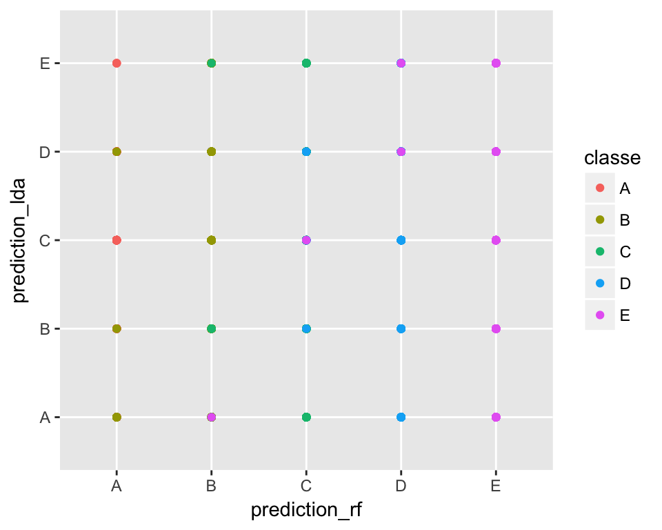

```r
qplot(prediction_rf, prediction_lda,color = classe, data = HARTesting)
```

Finally, we load the `testing` data file and predict the result using `rf` model as follows:

## Read test file

```r
testingI <- read.csv("./data/pml-testing.csv",  stringsAsFactors=FALSE, header = TRUE)
dim(testingI)
```

```
## [1]  20 160
```

```r
testing <- testingI[,names(testingI) %in% names(HARTraining)]
predict_result <- predict(modFit_rf, newdata = testing, predict.all = TRUE)
predict_result
```

```
##  [1] B A B A A E D B A A B C B A E E A B B B
## Levels: A B C D E
```

# Conclusion

In this project, we were able to fit a model that predicts with over 99 percent accuracy the class of dumbell exercises given a series of movements. A random forest model proved to be the most accurate model, however it is also computationally intensive and may take a long time if the number of variables increases greatly.